# Rで作図

2024-03-29

## Introduction

## Contact R server

- Input 133.45.178.25:8787
- Fill your ID and PW accordingly
  - ID: your first name
  - common PW: hogefuga1192+

## Contact from outside via VPN

- Set up your [VPN](https://www.cc.nagasaki-u.ac.jp/service/outside_the_university.html) app such as Cisco AnyConnect
- https://www.cc.nagasaki-u.ac.jp/service/outside_the_university.html
- Before connecting the R server, start the VPN

## ID /PW

- ID: your first name in small letter all
- PW: your first name in small letter all
- Beware of
  - CAPITAL / small letter
  - typo

## Project, file, and expansion

- Project
  - A place (folder) to save all related to a certain analysis
- file
  - A file to save a R code.
  - Its substance is a .txt file
- expansion
  - a string to distinguish file type.
  - In R, use .r after a file name. Eg.) hoge.r

## Lesson

### NO using Japanese character

1. Make a project entitled “rgraphics.rproj”
2. Make a R file entitled “rgraphics.r”
3. Write your code as follows:
4. Save the R file
5. Show your results

```r
library(sf)
library(tidyverse)
```

## Fundamental operation

## Where to write your code

1. Source pane (topleft, Crtrl+1)
2. Console pane (Bottomleft, Ctrl+2)
3. Environment pane (Topright)
4. Output pane (Bottomright)

## Read library

- Whenever you start the R, read the library first.
- Library is a mass of functions for specific purposes.
  - R is a station integrating libraries.

```r
library(sf)
library(tidyverse)
```

## NOTE

- Once you install a library, you need not to reinstall it.
- Once you load a library, you need not to load it again.

```r
# If necessary, comment out the target code.
# install.packages("tidyverse")
library(tidyverse)
```

## Calculation

- We can use the R as a calculator

```r
1+2+3+4+5+6+7+8+9+10
```

```
## [1] 55
```

```r
sum(1:10)
```

```
## [1] 55
```

## Calculation (Continued)

- We can use the R as a calculator

```r
1*2*3*4*5*6*7*8*9*10
```

```
## [1] 3628800
```

```r
prod(1:10)
```

```
## [1] 3628800
```

## Calculation (Continued)

- We can use the R as a calculator

```r
log(1*2*3*4*5*6*7*8*9*10)
```

```
## [1] 15.10441
```

```r
log10(prod(1:10))
```

```
## [1] 6.559763
```

## Read data

- R can read variety of files including *rds*, *csv*, *xlsx*, *dta*, and others.
- This time, we read an MSExcel file.
- Procedure
  1. Obtain a certain target data
  2. Upload the MSExcel file (.xlsx) onto your project folder.
  3. Read the data following the code.

## Show the data

- Run the assigned object
- Frequently-used variable type
  - **dbl**: Double
  - **int**: Integer
  - **chr**: Character
  - **dttm**: date and time (POSIXt)
  - **fct**: factor
- Depending on the type, what we can do is subject to change.

## Assignment

- Assign data, figure, and others into an object
- Free to name the object by your own
- Available to succeed

```r
logresults <- log(1*2*3*4*5*6*7*8*9*10)
logresults
```

```
## [1] 15.10441
```

## Assignment

- Download four .rds data file from my GitHub (https://github.com/yuzuruu/lecture/tree/main/r_workshop)
- Upload the data onto your RStudio server
- Read any of the data.

## Read objects

```r
junior <-
  readr::read_rds("seniority_data_tutorial_college.rds")
high <-
  readr::read_rds("seniority_data_tutorial_high.rds")
college <-
  readr::read_rds("seniority_data_tutorial_college.rds")
university <-
  readr::read_rds("seniority_data_tutorial_university.rds")
```

## Frequently-used operators

- <- : assign an object at right to one at left
  - shortcut: Alt+-
- %>% : assign left-hand-side object into the first argument of the right-hand-side function
  - shortcut: Ctrl+Shift+m

## Combine the data

```r
data_seniority <-
  junior %>%
  # bind the object
  # NOTE
  # Name of variables and the N. of variables should be the same.
  dplyr::bind_rows(high) %>%
  dplyr::bind_rows(college) %>%
  dplyr::bind_rows(university)
```

## filter

```r
# filter
data_seniority_filtered <-
  data_seniority  %>%
  # make a subset of the data using dplyr::filter() function
  # NOTE
  # Multiple conditions are available.
  dplyr::filter(
    school == "university"
  )
# print content of the object
data_seniority_filtered
```

```
## # A tibble: 583,200 × 9
##    type   gender school age_class length_service industry size  year       value
##    <fct>  <fct>  <fct>  <fct>     <fct>          <fct>    <fct> <date>     <dbl>
##  1 regul… male   unive… under_19  0_years        MINING … over… 2019-06-01    NA
##  2 regul… male   unive… under_19  0_years        MINING … over… 2018-06-01    NA
##  3 regul… male   unive… under_19  0_years        MINING … over… 2017-06-01    NA
##  4 regul… male   unive… under_19  0_years        MINING … over… 2016-06-01    NA
##  5 regul… male   unive… under_19  0_years        MINING … over… 2015-06-01    NA
##  6 regul… male   unive… under_19  0_years        MINING … over… 2014-06-01    NA
##  7 regul… male   unive… under_19  0_years        MINING … over… 2013-06-01    NA
##  8 regul… male   unive… under_19  0_years        MINING … over… 2012-06-01    NA
##  9 regul… male   unive… under_19  0_years        MINING … over… 2011-06-01    NA
## 10 regul… male   unive… under_19  0_years        MINING … over… 2010-06-01    NA
## # ℹ 583,190 more rows
```

## Frequently-used operators

- == :equivalent to
- != :NOT equivalent to
- &: and
- |: or
- %in%: any of (usually used with vector containing conditions)

## filter (Cont.)

```r
# filter with multiple variables
data_seniority_filtered <-
  data_seniority  %>%
  dplyr::filter(
    school == "university" & gender == "female"
  )
data_seniority_filtered
```

```
## # A tibble: 291,600 × 9
##    type   gender school age_class length_service industry size  year       value
##    <fct>  <fct>  <fct>  <fct>     <fct>          <fct>    <fct> <date>     <dbl>
##  1 regul… female unive… under_19  0_years        MINING … over… 2019-06-01    NA
##  2 regul… female unive… under_19  0_years        MINING … over… 2018-06-01    NA
##  3 regul… female unive… under_19  0_years        MINING … over… 2017-06-01    NA
##  4 regul… female unive… under_19  0_years        MINING … over… 2016-06-01    NA
##  5 regul… female unive… under_19  0_years        MINING … over… 2015-06-01    NA
##  6 regul… female unive… under_19  0_years        MINING … over… 2014-06-01    NA
##  7 regul… female unive… under_19  0_years        MINING … over… 2013-06-01    NA
##  8 regul… female unive… under_19  0_years        MINING … over… 2012-06-01    NA
##  9 regul… female unive… under_19  0_years        MINING … over… 2011-06-01    NA
## 10 regul… female unive… under_19  0_years        MINING … over… 2010-06-01    NA
## # ℹ 291,590 more rows
```

## filter (Cont.)

```r
# filter with multiple conditions
data_seniority_filtered <-
  data_seniority  %>%
  dplyr::filter(
    school %in% c("university", "college")
  )
data_seniority_filtered
```

```
## # A tibble: 1,749,600 × 9
##    type   gender school age_class length_service industry size  year       value
##    <fct>  <fct>  <fct>  <fct>     <fct>          <fct>    <fct> <date>     <dbl>
##  1 regul… male   colle… under_19  0_years        MINING … over… 2019-06-01    NA
##  2 regul… male   colle… under_19  0_years        MINING … over… 2018-06-01    NA
##  3 regul… male   colle… under_19  0_years        MINING … over… 2017-06-01    NA
##  4 regul… male   colle… under_19  0_years        MINING … over… 2016-06-01    NA
##  5 regul… male   colle… under_19  0_years        MINING … over… 2015-06-01    NA
##  6 regul… male   colle… under_19  0_years        MINING … over… 2014-06-01    NA
##  7 regul… male   colle… under_19  0_years        MINING … over… 2013-06-01    NA
##  8 regul… male   colle… under_19  0_years        MINING … over… 2012-06-01    NA
##  9 regul… male   colle… under_19  0_years        MINING … over… 2011-06-01    NA
## 10 regul… male   colle… under_19  0_years        MINING … over… 2010-06-01    NA
## # ℹ 1,749,590 more rows
```

## Draw a figure

## What to do

- Target
  - *Wage census* of Japan (2010-2019)
  - Make a line plot showing wage transition by length of service and age class
  - A basis of so-called “seniotiry payroll”
- Procedure
  1. Make a data set
  2. Draw the figure
  3. Check its aesthetics

## summarize to obtain aggregated data

```r
data_seniority_summary <-
  data_seniority %>%
  dplyr::filter(
    school == "university"
  ) %>%
  group_by(length_service, age_class) %>%
  summarise(
    Mean = mean(value, na.rm = TRUE)
  )
data_seniority_summary
```

```
## # A tibble: 108 × 3
## # Groups:   length_service [9]
##    length_service age_class  Mean
##    <fct>          <fct>     <dbl>
##  1 0_years        20-24      22.3
##  2 0_years        25-29      56.3
##  3 0_years        30-34      91.0
##  4 0_years        35-39      98.9
##  5 0_years        40-44     117.
##  6 0_years        45-49     129.
##  7 0_years        50-54     144.
##  8 0_years        55-59     147.
##  9 0_years        60-64     306.
## 10 0_years        65-69      94.4
## # ℹ 98 more rows
```

## plot in the beginning

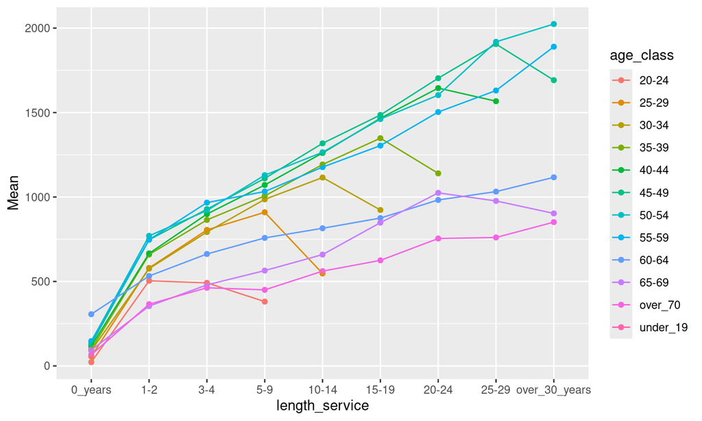

```r
line_seniority_summary <-
  data_seniority_summary %>%
  ggplot2::ggplot(
    aes(
      x = length_service,
      y = Mean,
      color = age_class,
      group = age_class
    )
  ) +
  geom_point() +
  geom_line()
line_seniority_summary
```

## plot in the beginning (Cont.)

### This figure does not satisfies us.

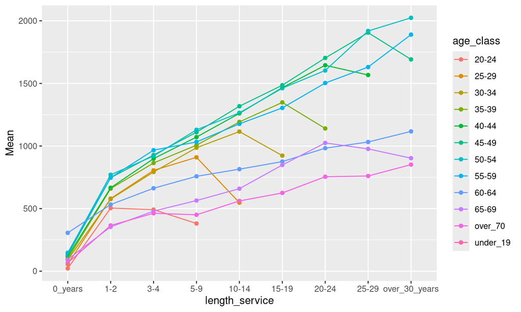

```r
line_seniority_summary
```